# HW1 Kryshchenko Anton

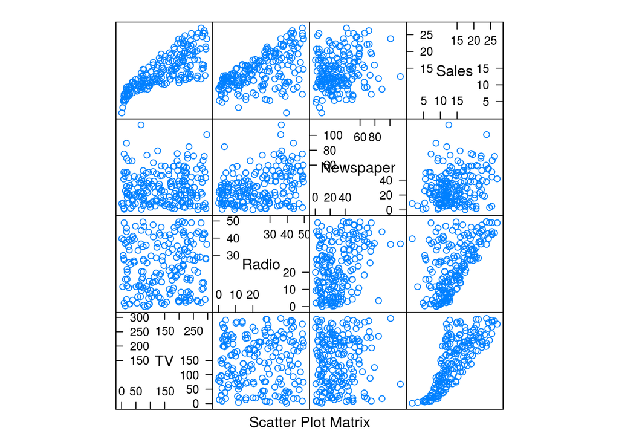

```r
library(MASS)
library(lattice)

adv.data <- read.csv("Advertising.csv")
adv.data$X <- NULL
splom(adv.data)
```

Построим простую модель

```r
model.simple <-lm(Sales ~ ., data = adv.data)
summary(model.simple)
```

```
##
## Call:
## lm(formula = Sales ~ ., data = adv.data)
##
## Residuals:
##     Min      1Q  Median      3Q     Max
## -8.8277 -0.8908  0.2418  1.1893  2.8292
##
## Coefficients:
##              Estimate Std. Error t value Pr(>|t|)
## (Intercept)  2.938889   0.311908   9.422   <2e-16 ***
## TV           0.045765   0.001395  32.809   <2e-16 ***
## Radio        0.188530   0.008611  21.893   <2e-16 ***
## Newspaper   -0.001037   0.005871  -0.177     0.86
## ---
## Signif. codes:  0 '***' 0.001 '**' 0.01 '*' 0.05 '.' 0.1 ' ' 1
##
## Residual standard error: 1.686 on 196 degrees of freedom
## Multiple R-squared:  0.8972, Adjusted R-squared:  0.8956
## F-statistic: 570.3 on 3 and 196 DF,  p-value: < 2.2e-16
```

```r
model.simple
```

```
##
## Call:
## lm(formula = Sales ~ ., data = adv.data)
##
## Coefficients:
## (Intercept)           TV        Radio    Newspaper
##    2.938889     0.045765     0.188530    -0.001037
```

Здесь сразу видно, что Newspaper имеет очень большое значение p-value, а значит является малозначимым признаком => можем его выкинуть. Проверим это с помощью AIC:

```r
model.simple.AIC <- stepAIC(model.simple)
```

```
## Start:  AIC=212.79
## Sales ~ TV + Radio + Newspaper
##
##             Df Sum of Sq    RSS    AIC
## - Newspaper  1      0.09  556.9 210.82
## <none>                    556.8 212.79
## - Radio      1   1361.74 1918.6 458.20
## - TV         1   3058.01 3614.8 584.90
##
## Step:  AIC=210.82
## Sales ~ TV + Radio
##
##         Df Sum of Sq    RSS    AIC
## <none>                556.9 210.82
## - Radio  1    1545.6 2102.5 474.52
## - TV     1    3061.6 3618.5 583.10
```

```r
summary(model.simple.AIC)
```

```
##
## Call:
## lm(formula = Sales ~ TV + Radio, data = adv.data)
##
## Residuals:
##     Min      1Q  Median      3Q     Max
## -8.7977 -0.8752  0.2422  1.1708  2.8328
##
## Coefficients:
##             Estimate Std. Error t value Pr(>|t|)
## (Intercept)  2.92110    0.29449   9.919   <2e-16 ***
## TV           0.04575    0.00139  32.909   <2e-16 ***
## Radio        0.18799    0.00804  23.382   <2e-16 ***
## ---
## Signif. codes:  0 '***' 0.001 '**' 0.01 '*' 0.05 '.' 0.1 ' ' 1
##
## Residual standard error: 1.681 on 197 degrees of freedom
## Multiple R-squared:  0.8972, Adjusted R-squared:  0.8962
## F-statistic: 859.6 on 2 and 197 DF,  p-value: < 2.2e-16
```

Действительно, Newspaper откинулись, как малозначимый признак.

Теперь построим полиномиальную модель второй степени без предиктора Newspaper

```r
model.poly2 <- lm(Sales ~ poly(TV, Radio, degree = 2), data = adv.data)
summary(model.poly2)
```

```
##
## Call:
## lm(formula = Sales ~ poly(TV, Radio, degree = 2), data = adv.data)
##
## Residuals:
##     Min      1Q  Median      3Q     Max
## -5.0027 -0.2859 -0.0062  0.3829  1.2100
##
## Coefficients:
##                                 Estimate Std. Error t value Pr(>|t|)
## (Intercept)                     13.94780    0.04422 315.449   <2e-16 ***
## poly(TV, Radio, degree = 2)1.0  53.71298    0.62764  85.579   <2e-16 ***
## poly(TV, Radio, degree = 2)2.0  -9.99022    0.62778 -15.914   <2e-16 ***
## poly(TV, Radio, degree = 2)0.1  40.52042    0.62857  64.464   <2e-16 ***
## poly(TV, Radio, degree = 2)1.1 272.58577    8.82370  30.892   <2e-16 ***
## poly(TV, Radio, degree = 2)0.2   0.49390    0.62608   0.789    0.431
## ---
## Signif. codes:  0 '***' 0.001 '**' 0.01 '*' 0.05 '.' 0.1 ' ' 1
##
## Residual standard error: 0.6244 on 194 degrees of freedom
## Multiple R-squared:  0.986,  Adjusted R-squared:  0.9857
## F-statistic:  2740 on 5 and 194 DF,  p-value: < 2.2e-16
```

```r
model.poly2
```

```
##
## Call:
## lm(formula = Sales ~ poly(TV, Radio, degree = 2), data = adv.data)
##
## Coefficients:
##                    (Intercept)  poly(TV, Radio, degree = 2)1.0
##                        13.9478                         53.7130
## poly(TV, Radio, degree = 2)2.0  poly(TV, Radio, degree = 2)0.1
##                        -9.9902                         40.5204
## poly(TV, Radio, degree = 2)1.1  poly(TV, Radio, degree = 2)0.2
##                       272.5858                          0.4939
```

А также AIC

```r
model.poly2.AIC <- stepAIC(model.poly2)
```

```
## Start:  AIC=-182.5
## Sales ~ poly(TV, Radio, degree = 2)
##
##                               Df Sum of Sq    RSS    AIC
## <none>                                       75.6 -182.5
## - poly(TV, Radio, degree = 2)  5    5341.5 5417.1  661.8
```

```r
summary(model.poly2.AIC)
```

```
##
## Call:
## lm(formula = Sales ~ poly(TV, Radio, degree = 2), data = adv.data)
##
## Residuals:
##     Min      1Q  Median      3Q     Max
## -5.0027 -0.2859 -0.0062  0.3829  1.2100
##
## Coefficients:
##                                 Estimate Std. Error t value Pr(>|t|)
## (Intercept)                     13.94780    0.04422 315.449   <2e-16 ***
## poly(TV, Radio, degree = 2)1.0  53.71298    0.62764  85.579   <2e-16 ***
## poly(TV, Radio, degree = 2)2.0  -9.99022    0.62778 -15.914   <2e-16 ***
## poly(TV, Radio, degree = 2)0.1  40.52042    0.62857  64.464   <2e-16 ***
## poly(TV, Radio, degree = 2)1.1 272.58577    8.82370  30.892   <2e-16 ***
## poly(TV, Radio, degree = 2)0.2   0.49390    0.62608   0.789    0.431
## ---
## Signif. codes:  0 '***' 0.001 '**' 0.01 '*' 0.05 '.' 0.1 ' ' 1
##
## Residual standard error: 0.6244 on 194 degrees of freedom
## Multiple R-squared:  0.986,  Adjusted R-squared:  0.9857
## F-statistic:  2740 on 5 and 194 DF,  p-value: < 2.2e-16
```

Здесь видно, что нужно откинуть малозначимый предиктор Radio^2 => получаем такую модель

```r
model.final <- lm(Sales ~ TV + Radio + TV:Radio + I(TV^2), data = adv.data)
summary(model.final)
```

```
##
## Call:
## lm(formula = Sales ~ TV + Radio + TV:Radio + I(TV^2), data = adv.data)
##
## Residuals:
##     Min      1Q  Median      3Q     Max
## -4.9949 -0.2969 -0.0066  0.3798  1.1686
##
## Coefficients:
##               Estimate Std. Error t value Pr(>|t|)
## (Intercept)  5.137e+00  1.927e-01  26.663  < 2e-16 ***
## TV           5.092e-02  2.232e-03  22.810  < 2e-16 ***
## Radio        3.516e-02  5.901e-03   5.959 1.17e-08 ***
## I(TV^2)     -1.097e-04  6.893e-06 -15.920  < 2e-16 ***
## TV:Radio     1.077e-03  3.466e-05  31.061  < 2e-16 ***
## ---
## Signif. codes:  0 '***' 0.001 '**' 0.01 '*' 0.05 '.' 0.1 ' ' 1
##
## Residual standard error: 0.6238 on 195 degrees of freedom
## Multiple R-squared:  0.986,  Adjusted R-squared:  0.9857
## F-statistic:  3432 on 4 and 195 DF,  p-value: < 2.2e-16
```

```r
model.final
```

```
##
## Call:
## lm(formula = Sales ~ TV + Radio + TV:Radio + I(TV^2), data = adv.data)
##
## Coefficients:
## (Intercept)           TV        Radio      I(TV^2)     TV:Radio
##   5.1370622    0.0509203    0.0351623   -0.0001097    0.0010766
```

Получили хорошую модель с значительно меньшим RSE, чем в model.simple

Теперь разобьем данные на обучающую и тестовую выборку

```r
adv.data.train.i <- sample(nrow(adv.data), size=nrow(adv.data)*0.6)
adv.data.train <- adv.data[adv.data.train.i, ]
adv.data.test <- adv.data[-adv.data.train.i, ]

model.simple.train <- lm(Sales ~ . , data = adv.data.train)
summary(model.simple.train)
```

```
##
## Call:
## lm(formula = Sales ~ ., data = adv.data.train)
##
## Residuals:
##     Min      1Q  Median      3Q     Max
## -8.5517 -0.8080  0.2005  1.3196  3.0490
##
## Coefficients:
##              Estimate Std. Error t value Pr(>|t|)
## (Intercept)  2.814890   0.437651   6.432 2.93e-09 ***
## TV           0.047826   0.001911  25.028  < 2e-16 ***
## Radio        0.185830   0.011384  16.323  < 2e-16 ***
## Newspaper   -0.006378   0.008312  -0.767    0.444
## ---
## Signif. codes:  0 '***' 0.001 '**' 0.01 '*' 0.05 '.' 0.1 ' ' 1
##
## Residual standard error: 1.828 on 116 degrees of freedom
## Multiple R-squared:  0.8932, Adjusted R-squared:  0.8905
## F-statistic: 323.5 on 3 and 116 DF,  p-value: < 2.2e-16
```

```r
model.simple.train
```

```
##
## Call:
## lm(formula = Sales ~ ., data = adv.data.train)
##
## Coefficients:
## (Intercept)           TV        Radio    Newspaper
##    2.814890     0.047826     0.185830    -0.006378
```

По полученной регрессии предскажем Sales для adv.data.test

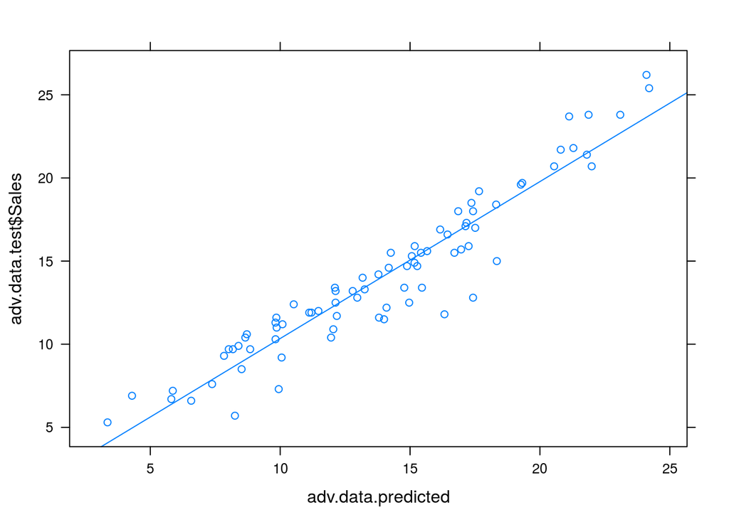

```r
adv.data.predicted <- predict(model.simple.train, adv.data.test)
xyplot( adv.data.test$Sales ~ adv.data.predicted , type = c("p","r"))
```

Теперь попробуем построить регрессию на model.final

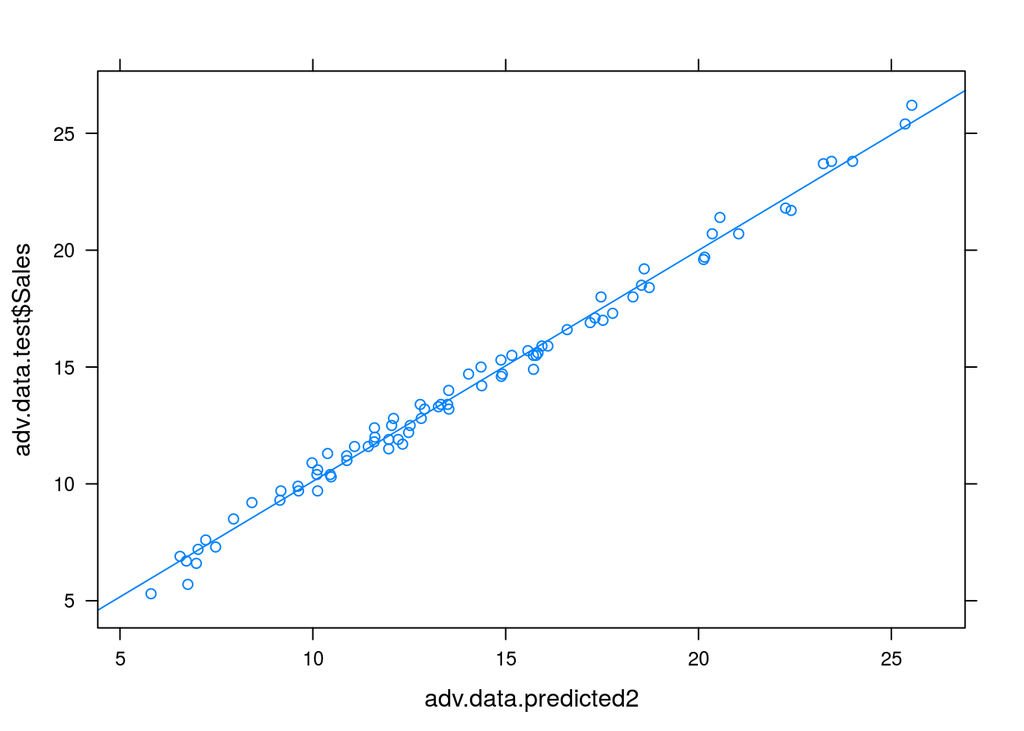

```r
model.final.train <- lm(Sales ~ TV + Radio + TV:Radio + I(TV^2), data = adv.data)
adv.data.predicted2 <- predict(model.final.train, adv.data.test)
xyplot( adv.data.test$Sales ~ adv.data.predicted2 , type = c("p","r"))
```

Теперь сравним RSS на обучающей и тестовой выборке:

```r
rss <- function(r) sqrt(sum(r^2) / length(r))

c(rss(model.simple.train$residuals), rss(adv.data.predicted - adv.data.test$Sales))
```

```
## [1] 1.797487 1.495131
```

```r
c(rss(model.final.train$residuals), rss(adv.data.predicted2 - adv.data.test$Sales))
```

```
## [1] 0.6159175 0.4416360
```

Мы видим, что для 2-й модели RSS значительно уменьшилось, т.е. построив полиномиальную модель и откинув незначительные признаки мы сильно улучшили нашу модель

Теперь попробуем поудалять значимые признаки:

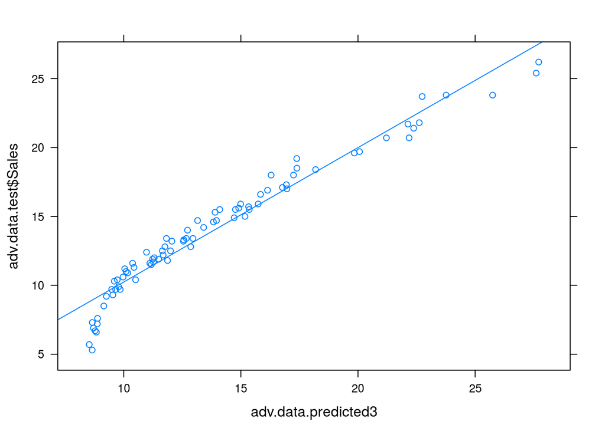

```r
model.without.TV.train <- lm(Sales ~ Radio + TV:Radio + I(TV^2), data = adv.data)
adv.data.predicted3 <- predict(model.without.TV.train, adv.data.test)
xyplot( adv.data.test$Sales ~ adv.data.predicted3 , type = c("p","r"))
```

```r
c(rss(model.without.TV.train$residuals), rss(adv.data.predicted3 - adv.data.test$Sales))
```

```
## [1] 1.179628 1.084013
```

Модель стала себя вести намного хуже - сильно увеличилось RSS

Посмотрим на модель без незначимых признаков и без нелинейности

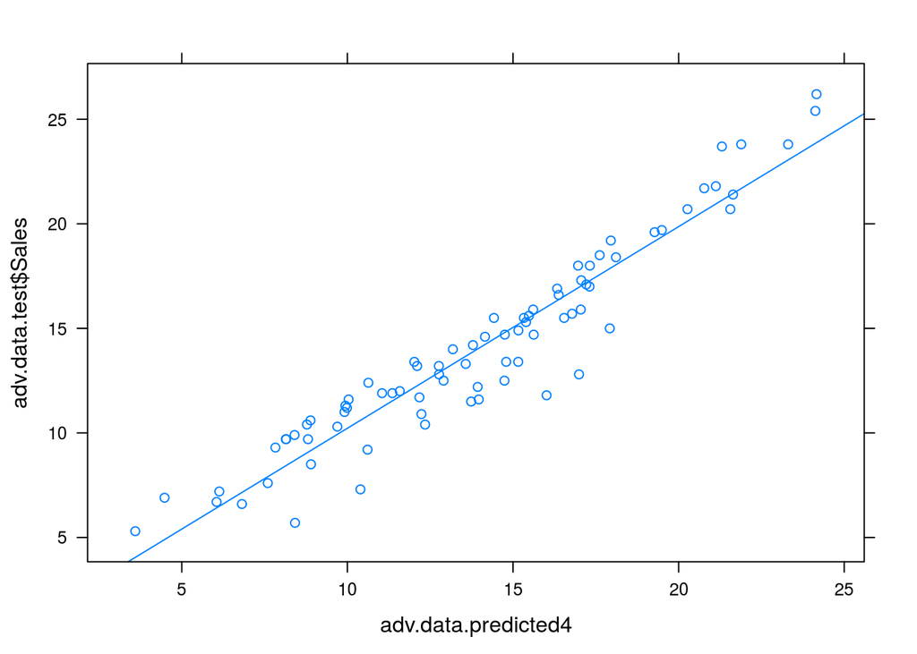

```r
model.without.poly.train <- lm(Sales ~ TV + Radio , data = adv.data)
adv.data.predicted4 <- predict(model.without.poly.train, adv.data.test)
xyplot( adv.data.test$Sales ~ adv.data.predicted4 , type = c("p","r"))
```

```r
c(rss(model.without.poly.train$residuals), rss(adv.data.predicted4 - adv.data.test$Sales))
```

```
## [1] 1.668703 1.426044
```

Модель стала себя вести намного хуже даже чем модель без значимого признака TV т.е. можно сделать вывод, что введение монотонной нелинейности очень сильно улучшает поведение на тестовой выборке

Таким образом окончательно оставляем model.final.train:

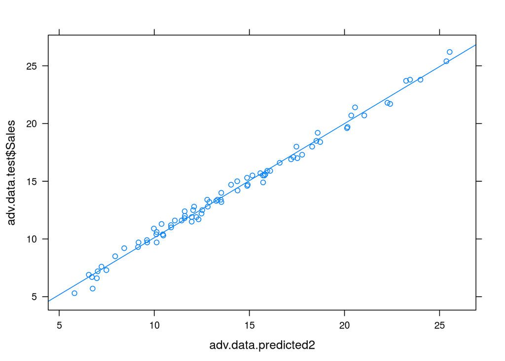

```r
xyplot( adv.data.test$Sales ~ adv.data.predicted2 , type = c("p","r"))
```

```r
c(rss(model.final.train$residuals), rss(adv.data.predicted2 - adv.data.test$Sales))
```

```
## [1] 0.6159175 0.4416360
```